# Machine Learning Autismo

Cristopher Valenzuela

10 de marzo de 2022

# Aplicación de machine learning.

Una vez obtenidos los genes diferencialmente expresados entre controles y autismo, procedemos a obtener datos que nos permiten aplicar algoritmos de machine learning con el objetivo de clasificar a los pacientes de los sanos. Aplicamos los distintos algoritmos para comparar la precisión de cada uno de ellos.

```r
#cargamos los datos guardados que contienen la variable dependiente y las predictoras que serian los genes, que obtuvimos del proyecto de R anterior.

datos.autismo<-read.csv("C:\\Users\\Cristopher\\Desktop\\datos omicos git\\autismo\\austismo_analisis\\Machine_learning_firmas\\top_genes.csv")

#eliminamos la primera columna, que son los identificadores de las muestras
row.names(datos.autismo) = datos.autismo$X
datos.autismo = datos.autismo[,-1]

datos.autismo[1:10,1:7]
```

```
##            diagnostico ILMN_1735360 ILMN_2075927 ILMN_3299478 ILMN_2210934
## GSM1033105           1  -1.12219307   0.80822327  -1.46840346  -0.69460155
## GSM1033106           1  -0.11504635   0.80822327  -1.29366251   0.57751411
## GSM1033107           1   0.02193304   0.38877404   1.18460015   0.19815997
## GSM1033108           1  -0.38507324   0.57960640   0.01387744   0.51554737
## GSM1033109           0  -0.34248662   0.80497915  -1.54717813  -0.23852907
## GSM1033110           0  -0.08795432  -0.08232094  -1.20381682   0.05250994
## GSM1033111           1   0.01813623  -0.16481130  -1.55571933  -0.07377526
## GSM1033112           0  -1.21380762   1.67062489  -0.75122399  -0.14563415
## GSM1033113           1   0.93607336   0.07979375  -0.35074004  -1.16401824
## GSM1033114           0  -0.44923689   1.41956576  -1.04193219   1.27534220
##            ILMN_3280402 ILMN_1813573
## GSM1033105  0.008956249    0.2203982
## GSM1033106 -0.040982526   -0.3163514
## GSM1033107 -0.725678157   -0.3232627
## GSM1033108 -0.205165212    1.2774123
## GSM1033109  0.185173974    0.6886360
## GSM1033110 -0.070210143    0.3649350
## GSM1033111 -0.257343985    0.1653713
## GSM1033112  0.143103448    1.3863804
## GSM1033113 -1.194767115    0.4694753
## GSM1033114 -0.054086084    1.4152209
```

Utilizaremos distintas tecnicas de Machine learning para intentar predecir a los pacientes con autismo versus los controles.

# Support Vector Machines (SVM)

```r
library(caret)
library(e1071)


#Procedemos a la particion de datos en 70 y 30.

t.svm<- createDataPartition(as.factor(datos.autismo$diagnostico), p = 0.7, list = F)

#creamos el modelo
mod.svm <- svm(as.factor(diagnostico) ~ ., data = datos.autismo[t.svm,])

mod.svm
```

```
##
## Call:
## svm(formula = as.factor(diagnostico) ~ ., data = datos.autismo[t.svm,
##     ])
##
##
## Parameters:
##    SVM-Type:  C-classification
##  SVM-Kernel:  radial
##        cost:  1
##
## Number of Support Vectors:  68
```

Veremos que tan bien predice el modelo.

```r
table(datos.autismo[t.svm,"diagnostico"], fitted(mod.svm), dnn = c("Actual","Predicho"))
```

```
##       Predicho
## Actual  0  1
##      0 27 13
##      1  5 59
```

Intentaremos predecir basándonos en el modelo anterior, utilizando los datos que no tomamos en la creación del modelo anterior.

```r
pred.svm<- predict(mod.svm, datos.autismo[-t.svm,])
table(datos.autismo[-t.svm,"diagnostico"],pred.svm,dnn = c("Actual","Predicho"))
```

```
##       Predicho
## Actual  0  1
##      0 11  5
##      1  2 25
```

Pese a que no hay muchos datos, no predice mal.

Podemos realizar un gráfico de la división, utilizando dos genes como ILMN_1735360 y ILMN_2075927.

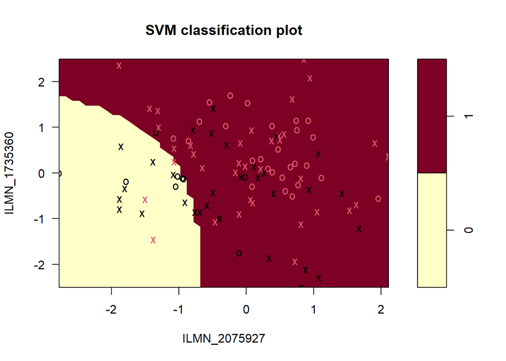

```r
plot(mod.svm , data = datos.autismo[t.svm,],  ILMN_1735360 ~ ILMN_2075927)
```

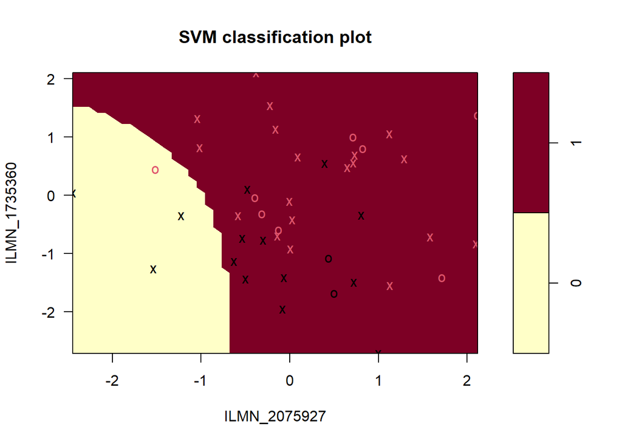

```r
plot(mod.svm , data = datos.autismo[-t.svm,],  ILMN_1735360 ~ ILMN_2075927)
```

# Naive Bayes.

```r
library(e1071)
library(caret)
library(naivebayes)

#creamos un conjunto de entrenamiento.

t.NB <- createDataPartition(as.factor(datos.autismo$diagnostico), p = 0.7, list = F)

#Intentamos predecir el diagnóstico de autismo al igual que en el apartado anterior.

mod.NB<-naiveBayes(as.factor(diagnostico) ~ ., data = datos.autismo[t.NB,])

mod.NB
```

```
##
## Naive Bayes Classifier for Discrete Predictors
##
## Call:
## naiveBayes.default(x = X, y = Y, laplace = laplace)
##
## A-priori probabilities:
## Y
##         0         1
## 0.3846154 0.6153846
##
## Conditional probabilities:
##    ILMN_1735360
## Y         [,1]      [,2]
##   0 -0.5141100 0.9433417
##   1  0.3509167 0.8898123
##
##    ILMN_2075927
## Y         [,1]      [,2]
##   0 -0.4414498 0.9447768
##   1  0.1523103 0.9516140
##
##    ILMN_3299478
## Y         [,1]      [,2]
##   0 -0.3415810 1.0250685
##   1  0.3697573 0.7719706
##
##    ILMN_2210934
## Y         [,1]      [,2]
##   0 -0.5271436 1.0095729
##   1  0.4030289 0.8133384
##
##    ILMN_3280402
## Y         [,1]      [,2]
##   0  0.5495895 0.9519777
##   1 -0.3417113 0.9260493
##
##    ILMN_1813573
## Y         [,1]      [,2]
##   0 -0.7210746 0.9898446
##   1  0.2542483 0.8228302
```

Vamos a probar el modelo en frente de las variables que no tome para predecir de las visualizaciones de validacion.

```r
pred.NB<- predict(mod.NB, datos.autismo[-t.NB,])

tab.NB <- table(datos.autismo[-t.NB,]$diagnostico, pred.NB, dnn = c("Actual","Predicha"))

confusionMatrix(tab.NB)
```

```
## Confusion Matrix and Statistics
##
##       Predicha
## Actual  0  1
##      0 11  5
##      1  3 24
##
##                Accuracy : 0.814
##                  95% CI : (0.666, 0.9161)
##     No Information Rate : 0.6744
##     P-Value [Acc > NIR] : 0.0324
##
##                   Kappa : 0.5914
##
##  Mcnemar's Test P-Value : 0.7237
##
##             Sensitivity : 0.7857
##             Specificity : 0.8276
##          Pos Pred Value : 0.6875
##          Neg Pred Value : 0.8889
##              Prevalence : 0.3256
##          Detection Rate : 0.2558
##    Detection Prevalence : 0.3721
##       Balanced Accuracy : 0.8067
##
##        'Positive' Class : 0
##
```

El "Accuracy" es de 0.814, este modelo tiene una buena discriminacion entre caso y controles.

# The k-nearest neighbors (KNN)

```r
#creamos los datos de entrenamiento
t.knn<- createDataPartition(as.factor(datos.autismo$diagnostico), p=0.7,list = F)
# 70% de datos de entrenamiento

train.knn <- datos.autismo[t.knn, ]
temp.knn <- datos.autismo[-t.knn, ]

v.ids.knn <- createDataPartition(temp.knn$diagnostico, p=0.7, list = F)

val.knn <- temp.knn[v.ids.knn,]
test.knn <- temp.knn[-v.ids.knn,]

pred1.knn <- knn3Train(train.knn[,2:7], val.knn[,2:7], train.knn[,1], k = 1)
#vamos a generar una matrix de confusion para ver como nos queda el resultado:

m.knn <- table(val.knn$diagnostico, pred1.knn, dnn = c("Actual", "Predichos"))

m.knn
```

```
##       Predichos
## Actual  0  1
##      0  7  4
##      1  6 14
```

Para ver que resultados tengo, si elijo 5 vecinos en vez de 1

```r
m.knn2 <- table(val.knn$diagnostico, pred1.knn, dnn = c("Actual", "Predichos"))

pred1.knn2 <- knn3Train(train.knn[,2:7], val.knn[,2:7], train.knn[,1], k = 5)

m.knn2
```

```
##       Predichos
## Actual  0  1
##      0  7  4
##      1  6 14
```

Eligiendo el mejor números de vecinos para la decisión.

```r
knn.automate <- function(tr_predictors, val_predictors, tr_target,
                         val_target, start_k, end_k)


for (k in start_k:end_k) {
  pred <- knn3Train(tr_predictors, val_predictors, tr_target, )
  tab <- table(val_target, pred, dnn = c("Actual", "Predichos") )
  cat(paste("Matriz de confusion para k = ",k,"\n"))
  cat("==============================\n")
  print(tab)
  cat("------------------------------\n")
  }

#ahora le pasamos las predicciones
knn.automate(train.knn[,2:7], val.knn[,2:7], train.knn[,1], val.knn[,1], 1,10)
```

```
## Matriz de confusion para k =  1
## ==============================
##       Predichos
## Actual  0  1
##      0  7  4
##      1  6 14
## ------------------------------
## Matriz de confusion para k =  2
## ==============================
##       Predichos
## Actual  0  1
##      0  7  4
##      1  6 14
## ------------------------------
## Matriz de confusion para k =  3
## ==============================
##       Predichos
## Actual  0  1
##      0  7  4
##      1  6 14
## ------------------------------
## Matriz de confusion para k =  4
## ==============================
##       Predichos
## Actual  0  1
##      0  7  4
##      1  6 14
## ------------------------------
## Matriz de confusion para k =  5
## ==============================
##       Predichos
## Actual  0  1
##      0  7  4
##      1  6 14
## ------------------------------
## Matriz de confusion para k =  6
## ==============================
##       Predichos
## Actual  0  1
##      0  7  4
```

[output cut: 15 more lines]

```
## ------------------------------
## Matriz de confusion para k =  9
## ==============================
##       Predichos
## Actual  0  1
##      0  7  4
##      1  6 14
## ------------------------------
## Matriz de confusion para k =  10
## ==============================
##       Predichos
## Actual  0  1
##      0  7  4
##      1  6 14
## ------------------------------
```

También se puede utilizar el paquete caret para este mismo objetivo.

```r
trcntrl<- trainControl(method = "repeatedcv", number = 10, repeats = 3)

# el numero de veces que se llevara a cabo la operacion es 10 y el numero de repeticiones 3.
# esto es nuestro dato de control.

caret_knn_fit <- train(as.factor(as.factor(diagnostico)) ~ ., data = train.knn,
                       method = "knn", trControl = trcntrl,
                       preProcess = c("center","scale"),
                       tuneLength = 10)

caret_knn_fit
```

```
## k-Nearest Neighbors
##
## 104 samples
##   6 predictor
##   2 classes: '0', '1'
##
## Pre-processing: centered (6), scaled (6)
## Resampling: Cross-Validated (10 fold, repeated 3 times)
## Summary of sample sizes: 93, 94, 94, 94, 94, 94, ...
## Resampling results across tuning parameters:
##
##   k   Accuracy   Kappa
##    5  0.7378788  0.4305503
##    7  0.7442424  0.4365594
##    9  0.7706061  0.4904456
##   11  0.7981818  0.5529003
##   13  0.7975758  0.5500679
##   15  0.8015152  0.5629232
##   17  0.7815152  0.5131353
##   19  0.7945455  0.5439142
##   21  0.7878788  0.5221454
##   23  0.7784848  0.4973486
##
## Accuracy was used to select the optimal model using the largest value.
## The final value used for the model was k = 15.
```

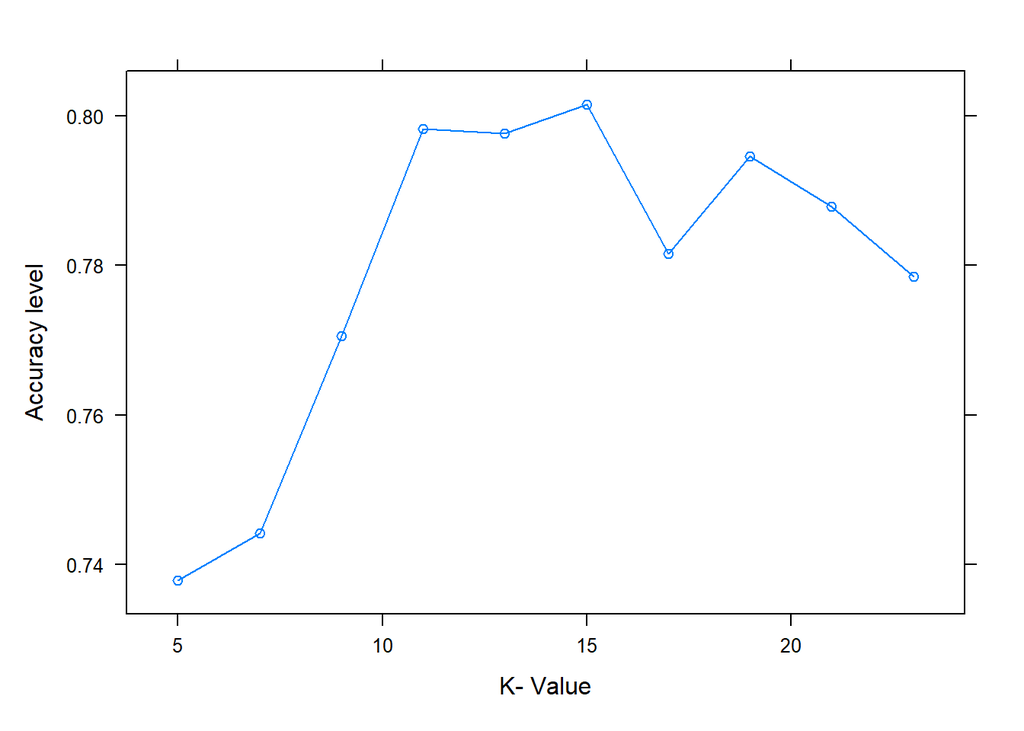

```r
plot(caret_knn_fit,type = "b", xlab="K- Value",ylab="Accuracy level")
```

```r
pred.knn.9 <- knn3Train(train.knn[,2:7], val.knn[,2:7], train.knn[,1], k=9, prob = T)

pred.knn.9[1:9]
```

```
## [1] "1" "1" "1" "0" "0" "1" "0" "0" "1"
```

Redes Neuronales

```r
library(nnet)
#segmentamos y creamos el conjunto de entrenamiento:

t.nnet<-createDataPartition(as.factor(datos.autismo$diagnostico), p= 0.7, list = F)

#creamos el modelo
mod.nnet <- nnet(as.factor(diagnostico) ~., data = datos.autismo[t.nnet,],
            size = 3, maxit = 10000, decay = .001, rang = 0.32,
            na.action = na.omit, skip = T)
apply(datos.autismo, 2, max)
```

```
##  diagnostico ILMN_1735360 ILMN_2075927 ILMN_3299478 ILMN_2210934 ILMN_3280402
##     1.000000     2.493523     2.120814     1.853294     2.090970     3.310769
## ILMN_1813573
##     2.345462
```

```r
mod.nnet <- nnet(as.factor(diagnostico) ~., data = datos.autismo[t.nnet,],
            size = 3, maxit = 10000, decay = .001, rang = 0.303,
            na.action = na.omit, skip = T)
```

El maximo es 3.310769, este numero 3.310769*0.303 = 1.003163.

Realizamos el plot con el modelo.

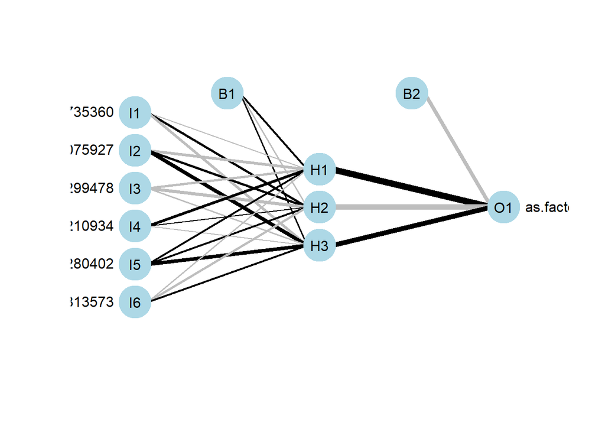

```r
library(NeuralNetTools)

NeuralNetTools::plotnet(mod.nnet)
```

```r
pred_nnet <- predict(mod.nnet, newdata = datos.autismo[-t.nnet,], type = "class")

#creamos una matriz de confusion

table(datos.autismo[-t.nnet,]$diagnostico, pred_nnet, dnn = c("Actual","Predichos"))
```

```
##       Predichos
## Actual  0  1
##      0  8  8
##      1  5 22
```

Creamos una curva ROC para ver que tan bien clasifica.

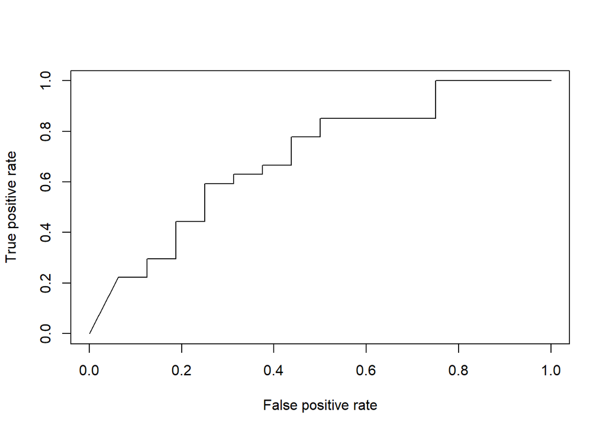

```r
library(ROCR)
pred2_nnet <- predict(mod.nnet, newdata = datos.autismo[-t.nnet,], type = "raw")
perf <- performance(prediction(pred2_nnet, datos.autismo[-t.nnet,"diagnostico"]),
                    "tpr", "fpr")

plot(perf)
```

En este caso observamos que no predice bien.

# Análisis Discriminante Lineal

```r
library(MASS)
t.ADL <- createDataPartition(as.factor(datos.autismo$diagnostico), p=0.7, list = F)

#seleccionamos los parametros de salida
mod.ADL <- lda(datos.autismo[t.ADL,2:7], datos.autismo[t.ADL,1])
```

```r
# Predecimos los valores, voy a utilizar el data frame original

datos.autismo[t.ADL, "Pred"] <- predict(mod.ADL, datos.autismo[t.ADL, 2:7])$class

#creamos una matriz de confusion

table(datos.autismo[t.ADL, "diagnostico"], datos.autismo[t.ADL, "Pred"], dnn = c("Actual","Predichos"))
```

```
##       Predichos
## Actual  0  1
##      0 32  8
##      1  7 57
```

```r
#Tenemos una variable de prediccion lleno de NAs, voy a cambiar los NAs con su prediccion.

datos.autismo[-t.ADL, "Pred"] <- predict(mod.ADL, datos.autismo[-t.ADL, 2:7])$class
```

```r
#podriamos hacer una table de doble entrada, una matriz de confusion.

table(datos.autismo[-t.ADL,"diagnostico"], datos.autismo[-t.ADL, "Pred"], dnn = c("Actual","Predicho"))
```

```
##       Predicho
## Actual  0  1
##      0 12  4
##      1  4 23
```